# Climate Changes in the US

Kaiyang Wu, Susan Lai, Miles Zhang

11/12/2022

> Code name: Climate Warriors

**Authors**:

*Kaiyang Wu kaiyaw@uw.edu, Susan Lai snl6@uw.edu, Miles Zhang hzhang44@uw.edu*

**Affiliation**:

*INFO-201: Technical Foundations of Informatics - The Information School - University of Washington*

**Date**: Autumn 2022

**Keywords**: climate change; greenhouse gas emissions; environment;

## Abstract

In our project, we are focusing on global warming in climate change and answer this question, **“what obvious change of greenhouse gas in climate to increase global warming in the last few years?”**. This question will help us learn about a more serious situation in our environment. It is not only a dangerous problem in the US but also a global issue. We should recognize it and know how to prevent it in person from learning about the question, and know how to do some actions.

## Introduction

Our project focuses on climate change in the US. We will find out the most impacting factor in the cause of climate change and put its importance into research. Collect data that causes the most serious problem in the US from the past and present to analyze how exactly it changed the climate in the last few years and what components have consisted in climate change. After analyzing the data, we will conclude with a solution to prevent it; and invoke people to take action to the suggestions we make to stop climate change from badly breaking up the environment where we are presently living. Additionally, to have them see what the future will look like if we don’t take action. Doing all these steps can help advance our data to get reasonable evidence for the cause of it and may answer the questions that limit and allow us to understand the reasoning behind climate change.

## Problem Domain

### Direct Stakeholders

Direct stakeholders are the people who interact and work with a research topic almost every day. Some direct stakeholders are journalists and government officials because they are working on the project of the exploration of climate change, its effects, and solutions. Working with the topic can benefit them from people reading their articles or statements about climate change. Additionally, they allow others to learn and research more about the topic rather than having to find data ourselves. It benefits both sides of direct and indirect stakeholders by delivering and receiving the message of how the effects of climate change are threatening in the future.

### Indirect Stakeholders

The indirect stakeholders could be people reading the articles, social media outputs, and projects about climate change. They could be an indirect stakeholder because when they read the news about climate change, people could be thinking of ways how they can also help climate change. For example, they would use other transportation to get to places rather than a vehicle with gas. They are not working on research about the effects of climate change but on how they can change their lifestyle or may not change anything in their lifestyle. Either way, what they do in their lifestyle shows how they can be an indirect stakeholder.

### Harms

We might notice that the data that we found do not comfort our expectations. We cannot find the resources to locate and address our question in the searching and analyzing process. Also, most resources do not have credible sources. Our immature analyzing skills also will make mistakes and misunderstandings in information and data analysis. As “Data Feminism” said, all data analysis will exist biases and prejudices from the researchers, we also cannot exclude this probability in our data analysis. Since we are learning how we analyze the data and we still have different perspectives problems reflected in our disabilities in data collection and analysis. So, It may end up including incorrect information in this project and confuse people who review this project.

### Benefits

We are able to have the opportunity to do research on global warming and climate change in the US. We are doing the “teach” thing — first, we study and collect the data about climate change in the US, and then we do our analysis with our understanding of climate change and let more people know about the dangers of climate change, make more people research it and people can work together to prevent climate change to a worse situation. It is not only the topic of weather in the US, but it also is how we get more people interested in this topic. If people read our article and get inspired, they may change their attitudes and opinions towards climate change which potentially pushes the progress of solving the problem of climate change.

## Research Questions

1. Which greenhouse gasses omit the most?

   Finding what greenhouse gasses omit the most will help discover how to decrease climate change. Some of the greenhouse gasses are carbon dioxide, methane, nitrous oxide, etc. Those gasses are often produced by humans with their work and lifestyles. Therefore, finding out the main reason with the factor of knowing the greenhouse gasses will help climate change decrease in the future.
2. What are the indicators of climate change?

   We need to find indicators that support climate change in the US and try to abstract the data and trends. The indicators can also contribute to the prediction of future climate change paths. This question is important because some indicators that are correlated with climate change are not very known to the public, and are sometimes missing from research or projects like this one.
3. How does the climate extremes index change over time?

## The Dataset

| Dataset | Number of Observations | Number of Variables |
| --- | --- | --- |
| U.S. Greenhouse Gas Emissions by Gas, 1990–2020 | 37 | 5 |
| U.S. Climate Extremes Index (CEI) | 113 | 1 |
| Contiguous U.S. Average Temperature | 126 | 3 |
| Contiguous U.S. Maximum Temperature | 126 | 3 |
| Contiguous U.S. Minimum Temperature | 126 | 3 |

1. **U.S. Greenhouse Gas Emissions by Gas Sector, 1990–2020 (Environmental Protection Agency, 2022)**

   The greenhouse is highly related to climate change, and the dataset indicates the gas emissions by gas types from 1990 to 2020, which is helpful for resolving our first research question revolving around the relationship between greenhouse gas and the national climate change trends by giving us the gas emission sources and the type of gas that is prevalent in greenhouse gas emissions.

   This dataset is collected by the United States Environmental Protection Agency in 2022, in order to collect and track the data related to climate change in the U.S. EPA has two key programs that provide data on greenhouse gas emissions in the United States: the Inventory of U.S. Greenhouse Gas Emissions and Sinks and the Greenhouse Gas Reporting Program, collaborating with hundreds of experts representing more than a dozen U.S. government agencies, academic institutions, industry associations, consultants and environmental organizations. The U.S. government and citizens are likely to benefit from the dataset. The data is credible as it’s collected by an agency of the United States government.

   **Summary Information**:

   This dataset has 31 years of observation, and collected data for 4 kinds of gasses.

   For carbon dioxide, the year when the gas is emitted the most is 2005. For methane, it’s 2005. And for nitrous oxide and other gasses, it’s 1996 and 2020

   **Aggregate Table**:

   | Gas.Type | Total.Emission |
   | --- | --- |
   | Carbon.dioxide | 172806.96 |
   | HFCs..PFCs..SF6..and.NF3 | 4621.35 |
   | Methane | 22099.64 |
   | Nitrous.oxide | 14066.24 |

   > The table includes four types of carbon emissions and the total amount it omitted. Calculating the total amount lets us recognize which greenhouse gasses omit the most to find solutions to reduce them. Additionally, showing the total amount instead of each year’s emissions can have a simple graph for readers to observe.
2. **U.S. Climate Extremes Index (CEI) (NOAA National Center for Environmental Information, 2022a)**

   This dataset is a complex set of multivariate and multidimensional climate changes in the United States so that the results could be easily understood and used in policy decisions made by nonspecialists in the field. It is helpful for solving our second research question about the indicators of climate change as the dataset is calculated based on 4 indicators:
   1. monthly maximum and minimum temperature
   2. daily precipitation
   3. monthly Palmer Drought Severity Index (PDSI)
   4. landfalling tropical storm and hurricane wind velocity

   This dataset is collected by the National Center for Environmental Information and updated by month, in order to provide intuitive information for policy decisions and the general public. The data is calculated from other datasets including NCEI’s nClimGrid (Vose et al., 2014). The dataset is credible as it’s collected by a government authority.

   **Aggregate Table**:

   | Year | Index |
   | --- | --- |
   | 2021 | 0.00 |
   | 2020 | -8.00 |
   | 2019 | -4.62 |
   | 2018 | 0.32 |
   | 2017 | 6.10 |
   | 2016 | 6.66 |
   | 2015 | -2.42 |
   | 2014 | -14.74 |
   | 2013 | -8.64 |
   | 2012 | 32.14 |
   | 2011 | -24.00 |
   | 2010 | -3.46 |
   | 2009 | -8.68 |
   | 2008 | 2.42 |
   | 2007 | 11.24 |
   | 2006 | 3.46 |
   | 2005 | -13.16 |
   | 2004 | -2.30 |
   | 2003 | 9.12 |
   | 2002 | -8.96 |
   | 2001 | 2.70 |
   | 2000 | -4.32 |
   | 1999 | 10.48 |
   | 1998 | 16.00 |
   | 1997 | -25.40 |
   | 1996 | 15.96 |
   | 1995 | -15.20 |
   | 1994 | -4.80 |
   | 1993 | 11.02 |
   | 1992 | -4.04 |

   [output cut: 82 more lines]

   This dataset includes the average, maximum, and minimum temperatures across the contiguous United States region from 1895 to 2020. It helps us get to know the temperature changes in the past and helps resolve our first and second questions as it’s an important indicator of climate change.

   The dataset is collected by the National Center of Environmental Information and uses data from the U.S. Climate Divisions dataset, which is using the data from NCEI’s nClimGrid (Vose et al., 2014). The dataset is intended for the study of climate variability across the country. It is credible for the same reason as the dataset above as they are from the same authority.

## Charts

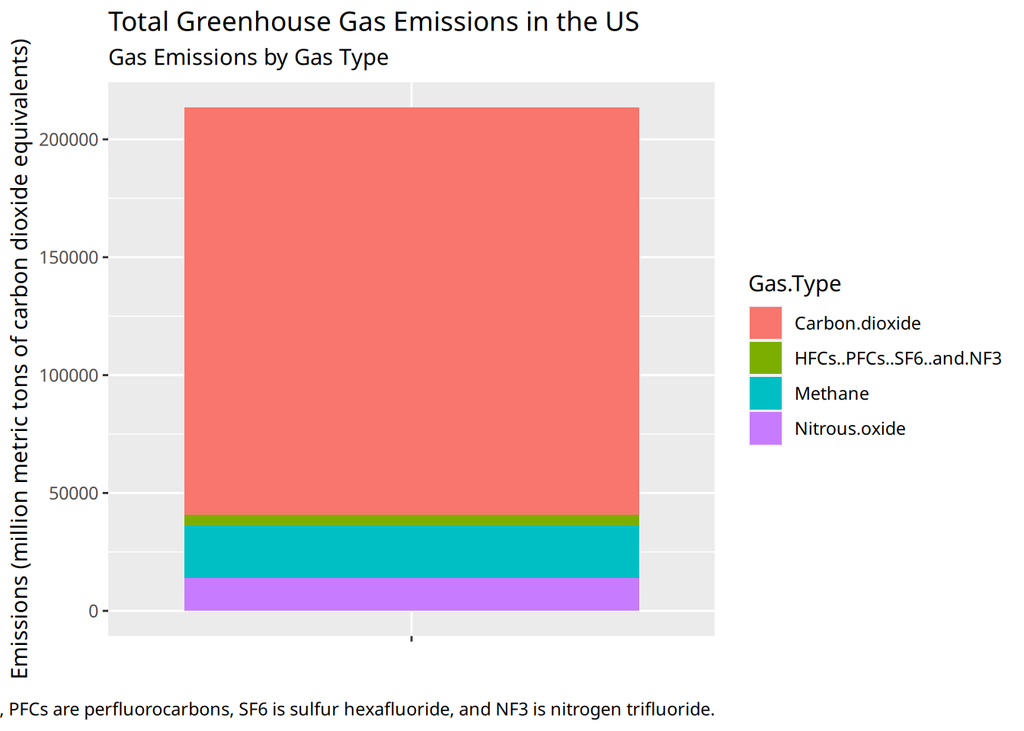

> This chart shows the total emissions of all types of greenhouse gasses from 1990 to 2020, and we can see that among all diffrent types of greenhouse gasses, CO2 (Carbonate Dioxide) has been emitted the most.

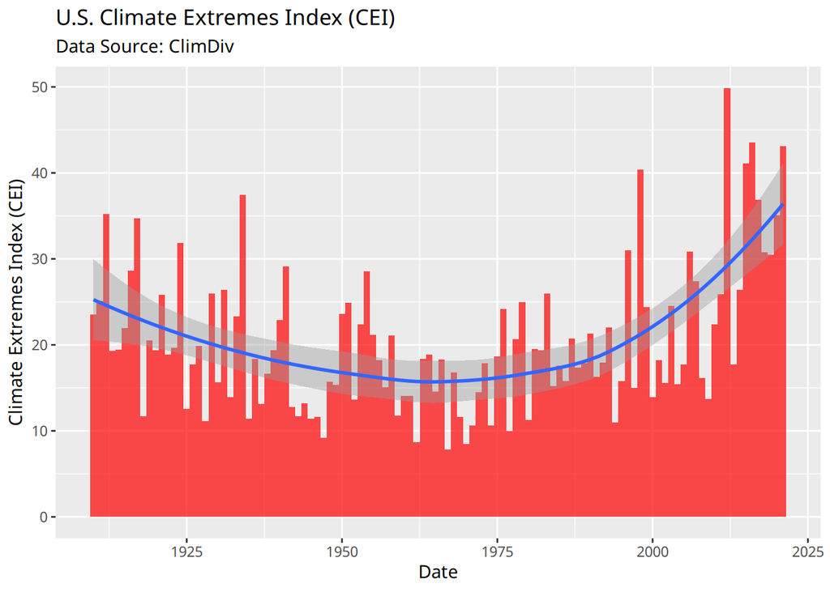

## Expected Implications

Technologists need to accompany people working on environmental protection and find out ways to address problems causing climate change to worsen. Designers should keep in mind the problem of climate change. The related institutions should publish the data table and analysis, to show the government and the public the real situation in the US, and make different kinds of people a more overall, clearer knowledge to take some actions. Policymakers should make policies focusing on how to protect the environment and write laws for judging behaviors based on current trends in climate change. The organization of protecting the environment can suggest people follow the policy and technologists’ research results to protect the environment together. The public population can follow the professional researchers’ advice to fix their “not good for the environment” behaviors, everyone makes some contributions to protect the environment. With these suggestions, people in the world can see how life-threatening climate change is for our future and take action together.

## Limitations

Two Limitations to climate change are; not fully understanding it and limits to the power of computers. We may not fully understand climate change because we do not know if humans are the cause of it and how much of the ocean, land, and other surfaces interfere (Legates, 2002). For instance, oceans may cause climate change because the current and temperature can be the main factor of it. Additionally, scientists track activities in parts of the world, and it limits the power of computers when there may be small important details on what is affecting climate change. Those small critical details may be tracking the activities of strong winds and the dry lands caused by forest fires (Legates, 2002). With the limitations, it may not be accurate to what causes climate change and is hard to discover. However, we can still get evidence from scientific data to still discover why climate change is happening and how we can try to prevent it.

## Acknowledgements

We would like to acknowledge the group members working on this project, the teaching assistant who helped us address our research questions, and the friend of Kaiyang Wu who gave great help with our project.

## References

1. Environmental Protection Agency. (2022). *Climate Change Indicators: U.S. Greenhouse Gas Emissions*. Retrieved October 29, 2022, from https://www.epa.gov/climate-indicators/climate-change-indicators-us-greenhouse-gas-emissions
2. NOAA National Center for Environmental Information. (2022). *U.S. climate extremes index (CEI). U.S. Climate Extremes Index (CEI) | National Centers for Environmental Information (NCEI)*. Retrieved October 29, 2022, from https://www.ncei.noaa.gov/access/monitoring/cei/
3. *Climate Change and Human Health: Racing to Curb the Ripple Effect*. (May 23, 2022). Retrieved October 29, 2022, from https://www.bayer.com/en/news-stories/climate-change-and-human-health?gclid=Cj0KCQjwnvOaBhDTARIsAJf8eVMI_iCxAyKFOe4DEypndFT36I15LQNhkpvq8i1XP__9H1yDulXpDOAaAjDvEALw_wcB
4. Legates, D. R. (2002). *Limitations of climate models as predictors of climate change*. National Center for Policy Analysis. Retrieved October 29, 2022, from https://www.ncpathinktank.org/pub/ba396
5. Vose, R., Applequist, S., Squires, M., Durre, I., Menne, M. J., Jr., C. N. W., Fenimore, C., Gleason, K., & Arndt, D. (2015, June 12). *NOAA monthly U.S. Climate Gridded Dataset (nclimgrid)*. National Centers for Environmental Information (NCEI). doi:10.7289/V5SX6B56
6. *Climate change impacts*. National Oceanic and Atmospheric Administration. (n.d.). Retrieved October 29, 2022, from https://www.noaa.gov/education/resource-collections/climate/climate-change-impacts
7. NOAA National Centers for Environmental information. (2022). *Climate at a Glance: National Mapping, Average Temperature*. Retrieved October 29, 2022 from https://www.ncdc.noaa.gov/cag/

## Appendix A

Questions for TA or instructor:

- Are the APA format in-citations correct?